# **Data Preparation & Machine Learning with Ebay Shill Bidding data**

Lucas Pontes

28 June 2022

**[SBD Dataset Web Page](https://archive.ics.uci.edu/ml/datasets/Shill+Bidding+Dataset)**

# **Introduction**

The Shill Bidding Data set `SBD` comprise eBay auctions with many different features, including the duration of the auctions, bidder tendency and class, among others (Alzahrani and Sadaoui, 2018). The aim of this report is to submit the data to different supervised and unsupervised machine learning methods after properly characterisation and preparation of the dataset. To achieve the best result a scaling method is applied alongside feature reduction methods, machine-learning methods applied had their performance and accuracy level measured and compared. At the end of this report, the supervised and unsupervised methods were identified in order to work with optimal performance in the Shill Bidding Dataset. The predictions related to normal and abnormal bidding behaviour of eBay users is capable of helping companies to identify scams and other undesirable users within the platform.

# **Data preparation**

## **Data characterisation**

Data characterisation is defined as the pre-processing phase of summarization of the different features and characteristics presents in the observations of a given data set, this process is typically accomplished by introducing the data to the viewer using statistics measure summaries, and presenting visually using graphs, like bar charts and scatter plots (Capozzoli, Cerquitelli and Piscitelli, 2016; Han, Kamber and Pei, 2012).

```
## # A tibble: 6,321 × 13
##    Record_ID Auction_ID Bidder_ID Bidder_Tendency Bidding_Ratio Successive_Outb…
##        <dbl>      <dbl> <chr>               <dbl>         <dbl>            <dbl>
##  1         1        732 _***i              0.2            0.4                0
##  2         2        732 g***r              0.0244         0.2                0
##  3         3        732 t***p              0.143          0.2                0
##  4         4        732 7***n              0.1            0.2                0
##  5         5        900 z***z              0.0513         0.222              0
##  6         8        900 i***e              0.0385         0.111              0
##  7        10        900 m***p              0.4            0.222              0
##  8        12        900 k***a              0.138          0.444              1
##  9        13       2370 g***r              0.122          0.185              1
## 10        27        600 e***t              0.155          0.346              0.5
## # … with 6,311 more rows, and 7 more variables: Last_Bidding <dbl>,
## #   Auction_Bids <dbl>, Starting_Price_Average <dbl>, Early_Bidding <dbl>,
## #   Winning_Ratio <dbl>, Auction_Duration <dbl>, Class <dbl>
```

```
## Rows: 6,321
## Columns: 13
## $ Record_ID              <dbl> 1, 2, 3, 4, 5, 8, 10, 12, 13, 27, 37, 38, 39, 4…
## $ Auction_ID             <dbl> 732, 732, 732, 732, 900, 900, 900, 900, 2370, 6…
## $ Bidder_ID              <chr> "_***i", "g***r", "t***p", "7***n", "z***z", "i…
## $ Bidder_Tendency        <dbl> 0.200000000, 0.024390244, 0.142857143, 0.100000…
## $ Bidding_Ratio          <dbl> 0.40000000, 0.20000000, 0.20000000, 0.20000000,…
## $ Successive_Outbidding  <dbl> 0.0, 0.0, 0.0, 0.0, 0.0, 0.0, 0.0, 1.0, 1.0, 0.…
## $ Last_Bidding           <dbl> 0.0000277778, 0.0131226852, 0.0030416667, 0.097…
## $ Auction_Bids           <dbl> 0.00000000, 0.00000000, 0.00000000, 0.00000000,…
## $ Starting_Price_Average <dbl> 0.9935928, 0.9935928, 0.9935928, 0.9935928, 0.0…
## $ Early_Bidding          <dbl> 0.0000277778, 0.0131226852, 0.0030416667, 0.097…
## $ Winning_Ratio          <dbl> 0.6666667, 0.9444444, 1.0000000, 1.0000000, 0.5…
## $ Auction_Duration       <dbl> 5, 5, 5, 5, 7, 7, 7, 7, 7, 7, 7, 7, 7, 7, 7, 7,…
## $ Class                  <dbl> 0, 0, 0, 0, 0, 0, 0, 1, 1, 1, 1, 0, 0, 1, 0, 0,…
```

```
##    Record_ID       Auction_ID    Bidder_ID         Bidder_Tendency
##  Min.   :    1   Min.   :   5   Length:6321        Min.   :0.00000
##  1st Qu.: 3778   1st Qu.: 589   Class :character   1st Qu.:0.02703
##  Median : 7591   Median :1246   Mode  :character   Median :0.06250
##  Mean   : 7536   Mean   :1241                      Mean   :0.14254
##  3rd Qu.:11277   3rd Qu.:1867                      3rd Qu.:0.16667
##  Max.   :15144   Max.   :2538                      Max.   :1.00000
##  Bidding_Ratio     Successive_Outbidding  Last_Bidding      Auction_Bids
##  Min.   :0.01176   Min.   :0.0000        Min.   :0.00000   Min.   :0.0000
##  1st Qu.:0.04348   1st Qu.:0.0000        1st Qu.:0.04793   1st Qu.:0.0000
##  Median :0.08333   Median :0.0000        Median :0.44094   Median :0.1429
##  Mean   :0.12767   Mean   :0.1038        Mean   :0.46312   Mean   :0.2316
##  3rd Qu.:0.16667   3rd Qu.:0.0000        3rd Qu.:0.86036   3rd Qu.:0.4545
##  Max.   :1.00000   Max.   :1.0000        Max.   :0.99990   Max.   :0.7882
##  Starting_Price_Average Early_Bidding     Winning_Ratio    Auction_Duration
##  Min.   :0.0000         Min.   :0.00000   Min.   :0.0000   Min.   : 1.000
##  1st Qu.:0.0000         1st Qu.:0.02662   1st Qu.:0.0000   1st Qu.: 3.000
##  Median :0.0000         Median :0.36010   Median :0.0000   Median : 5.000
##  Mean   :0.4728         Mean   :0.43068   Mean   :0.3677   Mean   : 4.615
##  3rd Qu.:0.9936         3rd Qu.:0.82676   3rd Qu.:0.8519   3rd Qu.: 7.000
##  Max.   :0.9999         Max.   :0.99990   Max.   :1.0000   Max.   :10.000
##      Class
##  Min.   :0.0000
##  1st Qu.:0.0000
##  Median :0.0000
##  Mean   :0.1068
##  3rd Qu.:0.0000
##  Max.   :1.0000
```

A first glance at `SBD` shows 6321 observations for 13 features, the first three columns represent the record ID, auction and the bidder respectively. The dplyr glimpse function displays all columns beside bidder ID as numeric, however, class and all IDs columns should be treated as a character class.

```
## # A tibble: 6,321 × 13
##    Record_ID Auction_ID Bidder_ID Bidder_Tendency Bidding_Ratio Successive_Outb…
##    <chr>     <chr>      <chr>               <dbl>         <dbl>            <dbl>
##  1 1         732        _***i              0.2            0.4                0
##  2 2         732        g***r              0.0244         0.2                0
##  3 3         732        t***p              0.143          0.2                0
##  4 4         732        7***n              0.1            0.2                0
##  5 5         900        z***z              0.0513         0.222              0
##  6 8         900        i***e              0.0385         0.111              0
##  7 10        900        m***p              0.4            0.222              0
##  8 12        900        k***a              0.138          0.444              1
##  9 13        2370       g***r              0.122          0.185              1
## 10 27        600        e***t              0.155          0.346              0.5
## # … with 6,311 more rows, and 7 more variables: Last_Bidding <dbl>,
## #   Auction_Bids <dbl>, Starting_Price_Average <dbl>, Early_Bidding <dbl>,
## #   Winning_Ratio <dbl>, Auction_Duration <dbl>, Class <fct>
```

```
##   Record_ID          Auction_ID         Bidder_ID         Bidder_Tendency
##  Length:6321        Length:6321        Length:6321        Min.   :0.00000
##  Class :character   Class :character   Class :character   1st Qu.:0.02703
##  Mode  :character   Mode  :character   Mode  :character   Median :0.06250
##                                                           Mean   :0.14254
##                                                           3rd Qu.:0.16667
##                                                           Max.   :1.00000
##  Bidding_Ratio     Successive_Outbidding  Last_Bidding      Auction_Bids
##  Min.   :0.01176   Min.   :0.0000        Min.   :0.00000   Min.   :0.0000
##  1st Qu.:0.04348   1st Qu.:0.0000        1st Qu.:0.04793   1st Qu.:0.0000
##  Median :0.08333   Median :0.0000        Median :0.44094   Median :0.1429
##  Mean   :0.12767   Mean   :0.1038        Mean   :0.46312   Mean   :0.2316
##  3rd Qu.:0.16667   3rd Qu.:0.0000        3rd Qu.:0.86036   3rd Qu.:0.4545
##  Max.   :1.00000   Max.   :1.0000        Max.   :0.99990   Max.   :0.7882
##  Starting_Price_Average Early_Bidding     Winning_Ratio    Auction_Duration
##  Min.   :0.0000         Min.   :0.00000   Min.   :0.0000   Min.   : 1.000
##  1st Qu.:0.0000         1st Qu.:0.02662   1st Qu.:0.0000   1st Qu.: 3.000
##  Median :0.0000         Median :0.36010   Median :0.0000   Median : 5.000
##  Mean   :0.4728         Mean   :0.43068   Mean   :0.3677   Mean   : 4.615
##  3rd Qu.:0.9936         3rd Qu.:0.82676   3rd Qu.:0.8519   3rd Qu.: 7.000
##  Max.   :0.9999         Max.   :0.99990   Max.   :1.0000   Max.   :10.000
##  Class
##  0:5646
##  1: 675
##
##
##
##
```

## **Exploratory Data Analysis**

```
## # A tibble: 6,321 × 13
##    Record_ID Auction_ID Bidder_ID Bidder_Tendency Bidding_Ratio Successive_Outb…
##    <chr>     <chr>      <chr>               <dbl>         <dbl>            <dbl>
##  1 1         732        _***i              0.2            0.4                0
##  2 2         732        g***r              0.0244         0.2                0
##  3 3         732        t***p              0.143          0.2                0
##  4 4         732        7***n              0.1            0.2                0
##  5 5         900        z***z              0.0513         0.222              0
##  6 8         900        i***e              0.0385         0.111              0
##  7 10        900        m***p              0.4            0.222              0
##  8 12        900        k***a              0.138          0.444              1
##  9 13        2370       g***r              0.122          0.185              1
## 10 27        600        e***t              0.155          0.346              0.5
## # … with 6,311 more rows, and 7 more variables: Last_Bidding <dbl>,
## #   Auction_Bids <dbl>, Starting_Price_Average <dbl>, Early_Bidding <dbl>,
## #   Winning_Ratio <dbl>, Auction_Duration <dbl>, Class <fct>
```

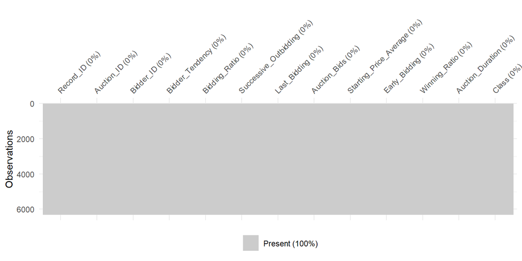

As displayed by the graphic generated by naniar function “vis_miss” on `SBD`, the data does not include any standard missing value.

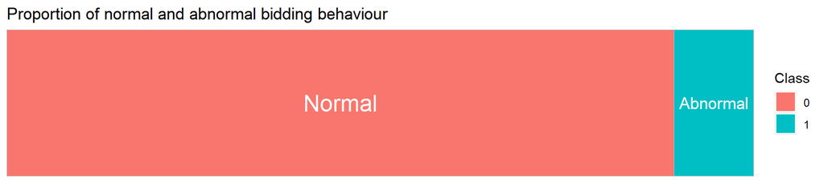

```
##
##    0    1
## 5646  675
```

```
##
##    0    1
## 0.89 0.11
```

As displayed by the treemap and proportion table above, only 10.7% (675 observations) of the biddings on `SBD` are considered abnormal. The graph above does a great job showing the proportion. The conventional use of pie charts is not recommended to display proportion, especially when the feature contains multiple unique observations or small fractions, Human perception does not comprehend angular proportions in pie charts as it should (Hunt, 2019).

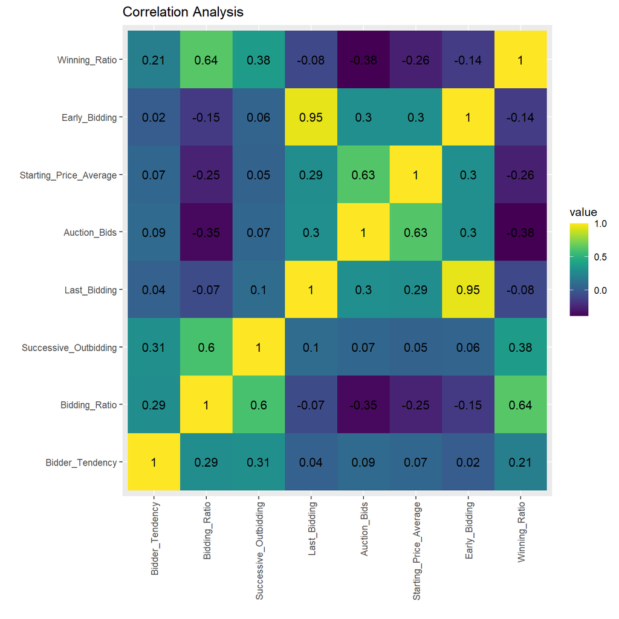

The heatmap above shows the correlation between all numerical features in a single graph. The ggplot graph above has a colourblind friendly colour palette and an added numerical scale, allowing the viewer to check the exact correlation between the variables, as an example, the positive correlation between early and last bidding features is notorious. Another noticeable correlation is the negative one between the winning ratio and auction bids, for further investigation, both is displayed in a scatter plot.

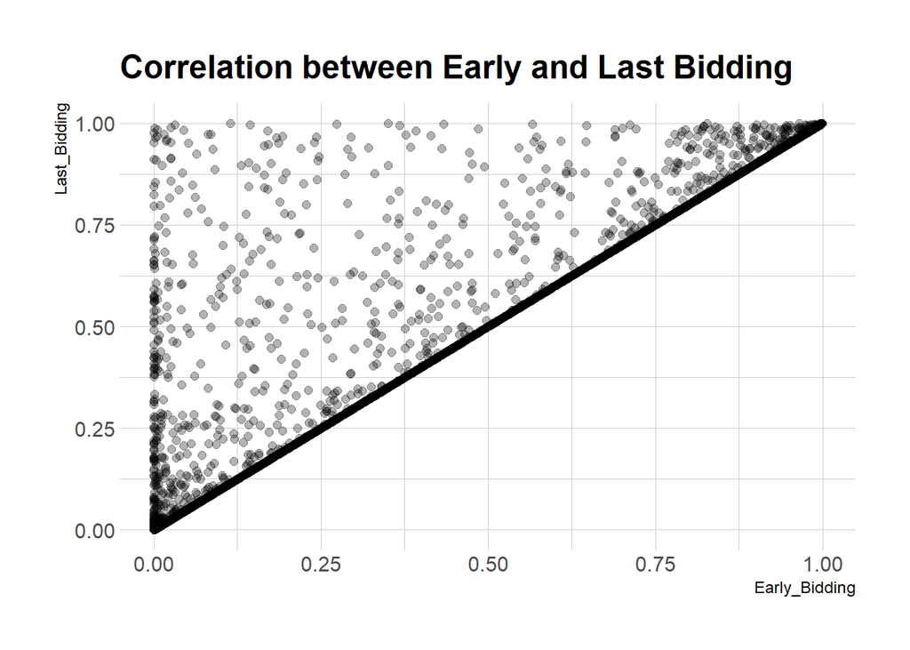

The scatter plot makes it noticeable why those two variables are so positive correlated, considering that the last bidding value can never be lower than the early bidding value. A positive slope can be found in the diagonal centre of the 2-dimensional plot, this line represents the values which were the same in both features.

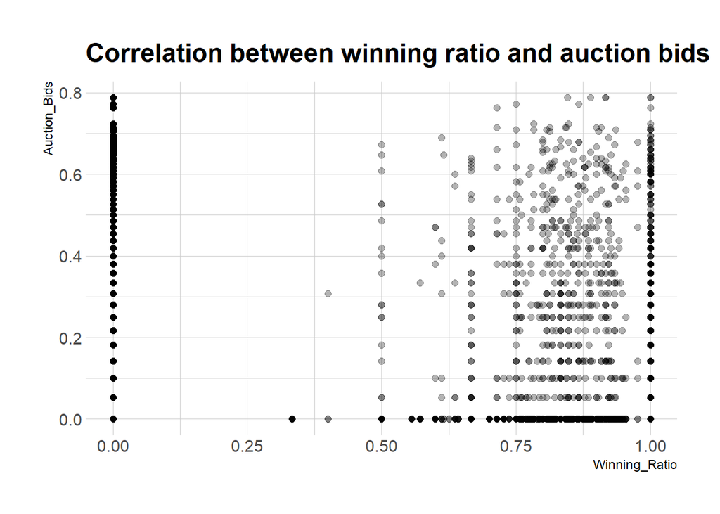

Different from the previous scatter plot, this time the features auction bids and winning ratio, which had a negative correlation in the heatmap representation, do not show any visible correlation. This interaction was tested when used as a predictor in a linear regression method.

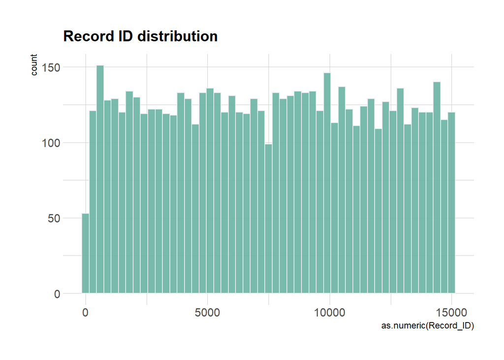

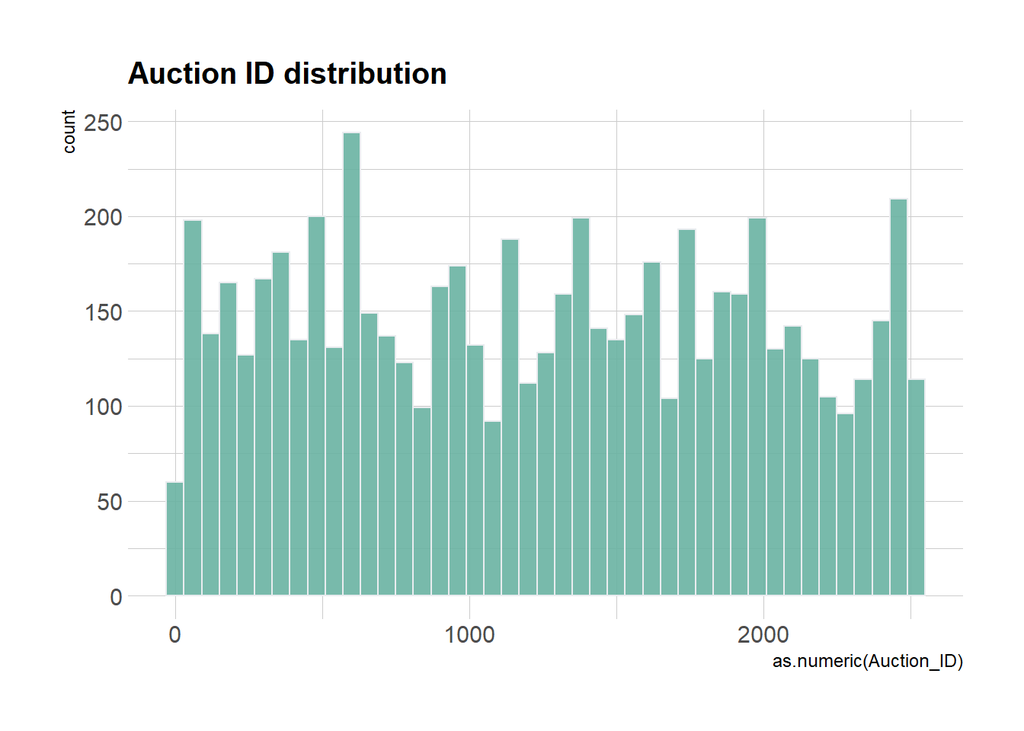

The histograms above display a clear difference between the distribution of the Auction and Record ID, as the x-axis of the Auction ID, is much shorter, this happens because many auctions are represented in the data set multiple times. Also, the Record ID displays some uniformity, even so not perfectly uniform, representing the absence of multiple observations with the same ID.

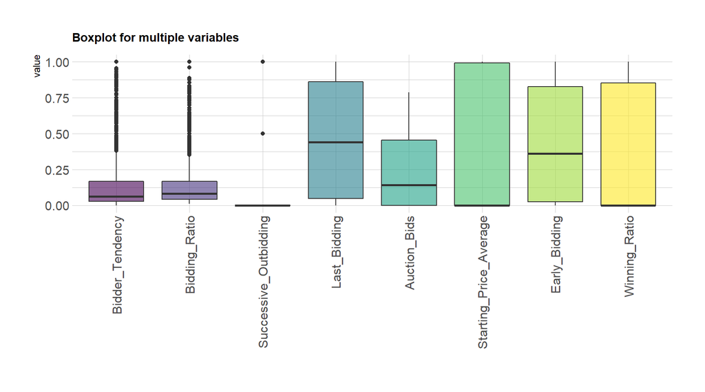

The Boxplot above shows the distribution of several numerical features with a range between 0 and 1. These 8 features were chosen to be represented by grouped boxplots since it is an exceptional alternative to viewing many distributions in a single graph, especially if the y-axis range matches all features. This figure is extremely informative, considering that it displays the distribution of the observations, the quartile range including the median, and the minimum and maximum values, which describe the range (Galarnyk, 2018).

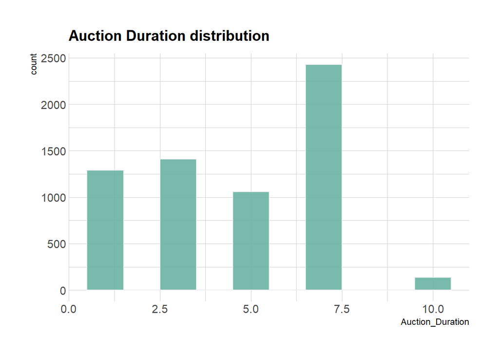

Despite being a numerical feature, the low number of distinct values causes the histogram to not be aesthetically pleasing, however, it shows the 5 distinct values 7,3,1,5 and 10 and how many times each one appeared in the auction duration column. This pattern suggests five fixed auction durations options that the platform allows the sellers to choose from.

| Bidder_Tendency_0 | 0.1224033 |
| --- | --- |
| Bidder_Tendency_1 | 0.3109790 |
| Bidding_Ratio_0 | 0.1017746 |
| Bidding_Ratio_1 | 0.3442676 |
| Successive_Outbidding_0 | 0.0166490 |
| Successive_Outbidding_1 | 0.8325926 |
| Last_Bidding_0 | 0.4502861 |
| Last_Bidding_1 | 0.5704626 |
| Auction_Bids_0 | 0.2276376 |
| Auction_Bids_1 | 0.2647969 |
| Starting_Price_Average_0 | 0.4656051 |
| Starting_Price_Average_1 | 0.5331813 |
| Early_Bidding_0 | 0.4236299 |
| Early_Bidding_1 | 0.4896741 |
| Winning_Ratio_0 | 0.3082423 |
| Winning_Ratio_1 | 0.8653224 |
| Auction_Duration_0 | 4.5970599 |
| Auction_Duration_1 | 4.7659259 |

The pivot table above points to a substantial difference in the group means value for most features when compared to normal and abnormal bidding patterns. The class feature is the dependable variable for machine learning models in the next steps.

## **Data cleaning**

The importance of identifying and removing missing values from the data prior to modelling is that it can reduce its accuracy and cause bias in the analysis (Analytics Vidhya, 2021). As shown before, there is not a single missing value in the data. However, sometimes the missing values appear as non-standard, a different format that includes strings named “NA”, “n/a”, “–” and many other possibilities. Unfortunately, it is near-impossible to check for all of them, especially in datasets with numerous observations and features. When it happens the feature type can only be categorical, since 0 in numeric features should not be considered meaningless (Sullivan, 2018). This section aims to check and remove non-standard missing values that may be present in the “Bidder_ID” column.

```
## [1] 0
```

Checking for common strings associated with non-standard missing values, the result of the analysis indicates the complete absence of them.

## **Feature engineering**

As an important stage preceding the machine learning modelling, this task requires the judgement of the data analyst and numerous trials and errors. Feature engineering is the act of transforming a given feature space with different tools, especially mathematical, with the main goal of improving the model performance (Khurana, Samulowitz and Turaga, 2018).The first step is removing unnecessary columns for the future tasks, the first three columns only include the IDs for the record, auction and bidder respectively and do not add any significance to the analysis.

```
##   Bidder_Tendency Bidding_Ratio Successive_Outbidding Last_Bidding Auction_Bids
## 1      0.20000000     0.4000000                     0 0.0000277778            0
## 2      0.02439024     0.2000000                     0 0.0131226852            0
## 3      0.14285714     0.2000000                     0 0.0030416667            0
## 4      0.10000000     0.2000000                     0 0.0974768519            0
## 5      0.05128205     0.2222222                     0 0.0013177910            0
## 6      0.03846154     0.1111111                     0 0.0168435847            0
##   Starting_Price_Average Early_Bidding Winning_Ratio Auction_Duration Class
## 1              0.9935928  0.0000277778     0.6666667                5     0
## 2              0.9935928  0.0131226852     0.9444444                5     0
## 3              0.9935928  0.0030416667     1.0000000                5     0
## 4              0.9935928  0.0974768519     1.0000000                5     0
## 5              0.0000000  0.0012417328     0.5000000                7     0
## 6              0.0000000  0.0168435847     0.8000000                7     0
```

As observed by the correlation of early and last biding in the scatter plot, the early bidding can never exceed the last bidding in value, however, what eventually happens is that the auction has no increase in price and culminate in the same value. To join the information of the two columns in one and add extra information to the future predictive model, a new column named “Bidding difference” is substituting them with the existing incremented value calculated by the difference between their prices.

```
##      Bidder_Tendency Bidding_Ratio Successive_Outbidding Auction_Bids
## 193      0.142857143    0.07142857                     0   0.00000000
## 423      0.500000000    0.10000000                     0   0.00000000
## 792      0.015384615    0.02941176                     0   0.47058824
## 906      0.008403361    0.05263158                     0   0.05263158
## 931      0.040000000    0.11111111                     0   0.00000000
## 1036     0.125000000    0.07142857                     0   0.00000000
## 1147     0.031250000    0.01960784                     0   0.64705882
## 2028     0.062500000    0.04545454                     0   0.18181818
## 2042     0.100000000    0.04761905                     0   0.14285714
## 2165     0.008196721    0.04000000                     0   0.28000000
## 2166     0.025000000    0.04000000                     0   0.28000000
## 2170     0.200000000    0.02857143                     0   0.48571429
## 2703     0.014084507    0.03225807                     0   0.41935484
## 2923     0.022222222    0.07142857                     0   0.00000000
```

[output cut: 78 more lines]

Calculating the difference between last and early bidding resulted in a feature with 25 negative values unexpected, suggesting that in these 25 observations the trade was concluded with the last bidding having a lower value than the early bidding, which is counterintuitive.

## **Data scaling**

The different orders of magnitude may bias the results since most machine learning algorithms calculate the output using Euclidean distance (Asaithambi, 2017). As seen in the distribution of the previous boxplots and histograms the numeric features contain some outliers, considering the putative relevance of these outliers in the machine learning analysis, the ideal transformation method will maintain the impact of these feature outliers in the output of the machine learning algorithm to be performed. The two regularly used scaling methods are standardization and normalization (GeeksforGeeks, 2020).

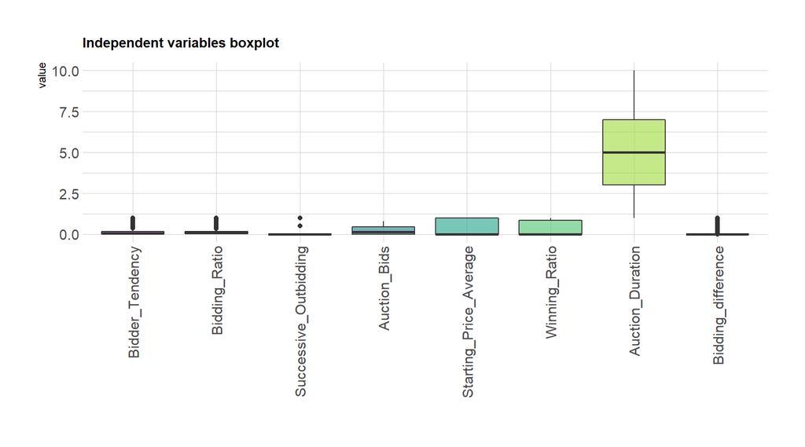

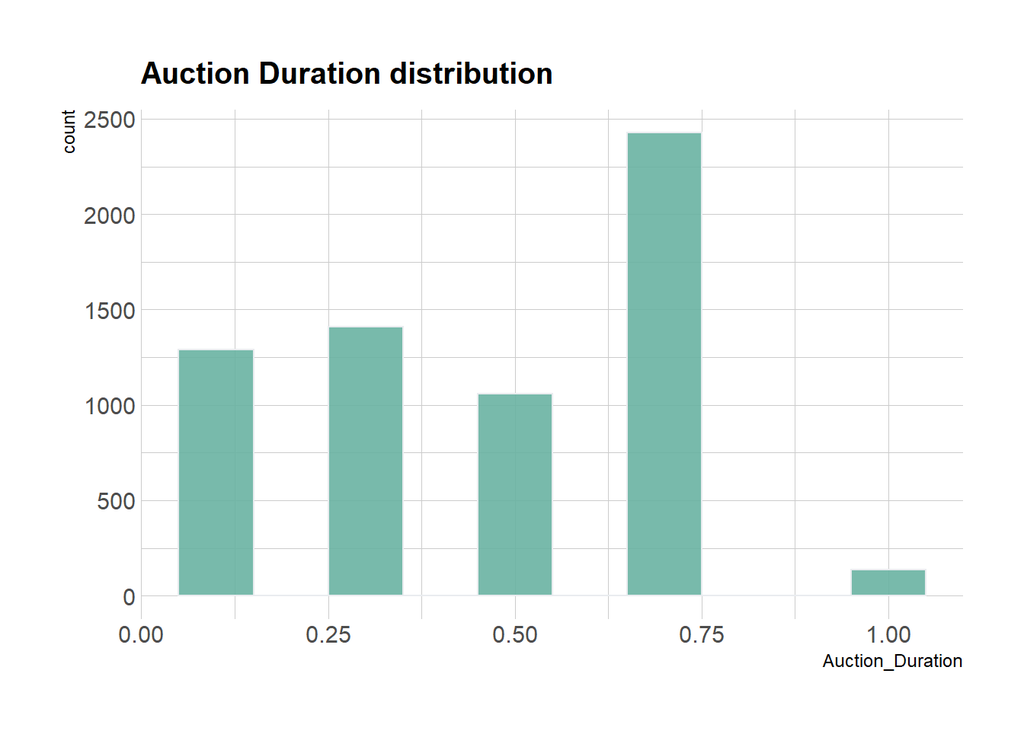

Since all other metrics range from 0 to 1, dividing the auction duration variable by 10 puts it in the same range. This reduces the chance of this variable impacting the model disproportionately compared to other features.

As displayed before, except for a few negative values in the Bidding difference column, all features range from 0 to 1, the data was probably been already pre-processed. Data scaling is necessary when the features of a dataset have a different range or order of magnitude (Roy, 2020), which is not the case for both, taking that and the fact that the outliers is important for the analysis, further data scaling was not employed.

# **Dimensionality reduction**

In pattern classification using a Machine Learning algorithm, the training vectors are evaluated by comparing them to the test split, a common problem that can reduce its accuracy is the large dimensionality of the data, and numerous features reducing the robustness of the pattern classifiers (Sharma and Paliwal, 2014). The main distinction between the two methods applied is that LDA is supervised, requiring labelled inputs, while PCA is unsupervised, ignoring class labels. LDA basis on discovering the feature subspace of highest separability between classes, while PCA focus in reproduce the topmost direction of variation in the features, the first component (PC1) accounting for the highest variation and the PC2 the second-best and so forth (Duvva, 2021).

## **Principal Component Analysis (PCA)**

Principal component analysis or PCA is an unsupervised technique, ignoring class labels. The main objective of performing a PCA prior to the Machine Learning technique is to increase interpretability while preserving statistical information (Jolliffe and Cadima, 2016).

```
## Importance of components:
##                           PC1    PC2    PC3     PC4     PC5     PC6     PC7
## Standard deviation     0.5618 0.4285 0.2541 0.24453 0.18119 0.17103 0.11862
## Proportion of Variance 0.4474 0.2603 0.0915 0.08476 0.04654 0.04147 0.01995
## Cumulative Proportion  0.4474 0.7077 0.7992 0.88399 0.93053 0.97200 0.99195
##                            PC8
## Standard deviation     0.07537
## Proportion of Variance 0.00805
## Cumulative Proportion  1.00000
```

The analysis resulted in 8 principal components, the first two explain 70% of the total variance. Five components were applied for the upcoming clustering algorithms, considering that this amount is enough to describe over 93% of the total variance (Hayden, 2018).

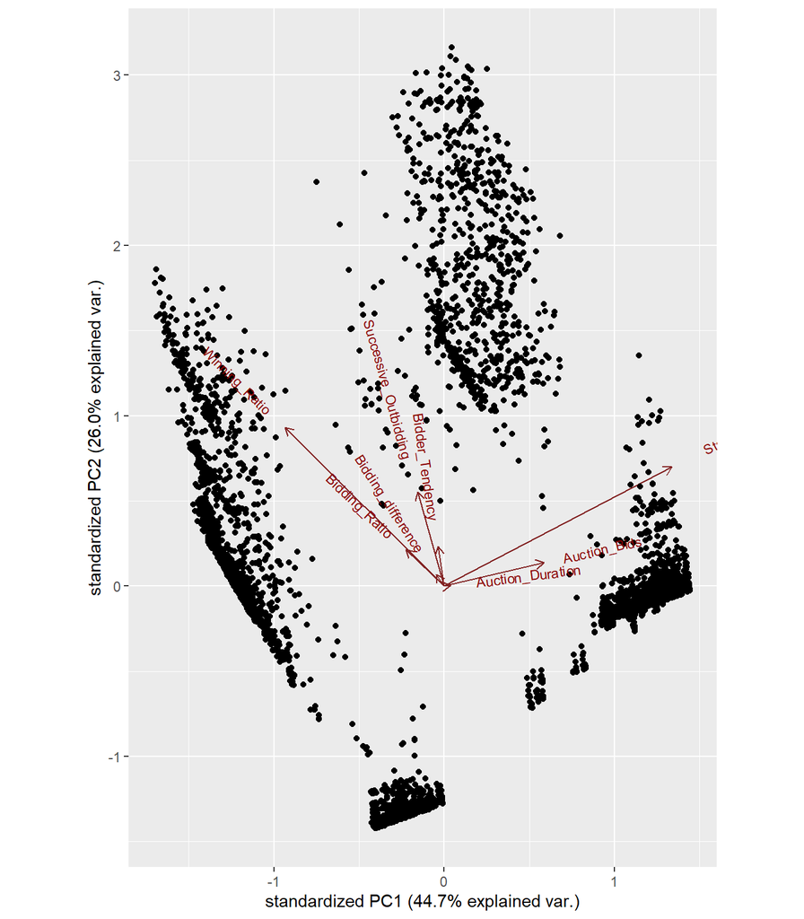

Originating from the centre point of the graph above the arrows indicate the contribution of each variable to the first two principal components. As seen, the variables “Auction Bids” and “Starting Price Average” contributes with high values to the first principal component, while “Successive Outbidding” and “Bidder Tendency” to the second principal component (Hayden, 2018).

## **Linear Discriminant Analysis (LDA)**

Another technique used to approach the high-dimensionality problem is the Linear discriminant analysis or LDA, which different from PCA, is a supervised technique that generally exceeds other techniques when applied to feature classification, LDA method reduces the number of features that fit in the different classes prior to classification while maintaining the classes well separated in this lower dimensional space (Sharma and Paliwal, 2014). The data was split into an 80% training, and 20% test split, this is the most common split of data considered one of the best ranges to avoid overfitting (Askpython, 2020).

```
## Call:
## lda(Class ~ ., data = training_set)
##
## Prior probabilities of groups:
##         0         1
## 0.8932173 0.1067827
##
## Group means:
##   Bidder_Tendency Bidding_Ratio Successive_Outbidding Auction_Bids
## 0       0.1230545     0.1013864            0.01638255    0.2261303
## 1       0.3067854     0.3494354            0.83611111    0.2630176
##   Starting_Price_Average Winning_Ratio Auction_Duration Bidding_difference
## 0              0.4664592     0.3058003        0.4595749         0.02693467
## 1              0.5272076     0.8628243        0.4848148         0.07725682
##
## Coefficients of linear discriminants:
##                               LD1
## Bidder_Tendency        0.14294249
## Bidding_Ratio          0.17712044
## Successive_Outbidding  7.96891614
## Auction_Bids           0.03795629
## Starting_Price_Average 0.04980094
## Winning_Ratio          0.32862007
## Auction_Duration       0.13459018
## Bidding_difference     0.24503511
```

The training data displays similar proportions of normal and abnormal bidding behaviour found in the SBD data, 90% and 10% respectively, including the similar group means values obtained in the exploratory data analysis section. Represented by the Coefficients of linear discriminants, these values indicate the predictor’s linear combination for the different features of the data applied in the decision rule in the LDA model. Since the class feature only contains two unique labels the analysis results in a single linear discriminant, LD1 (Zach, 2020).

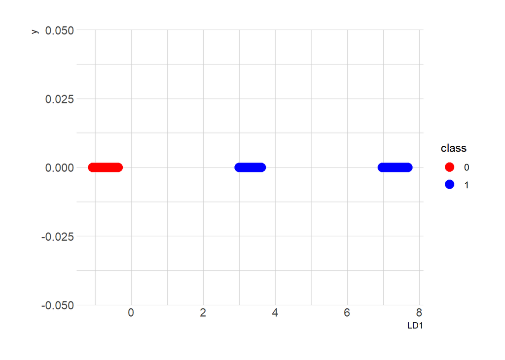

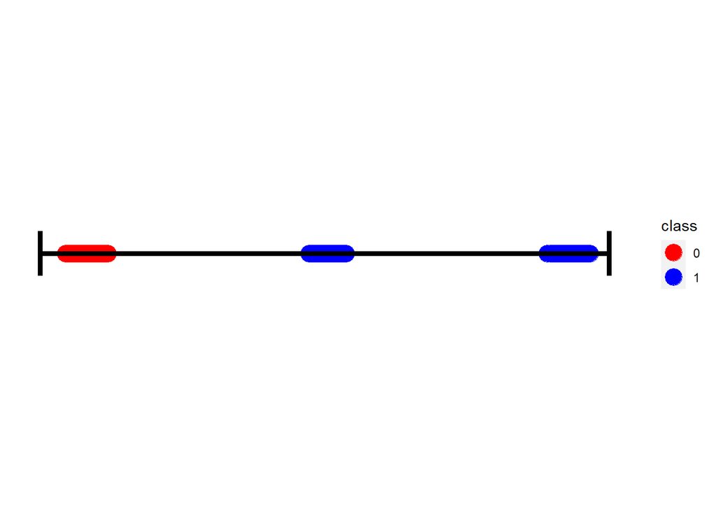

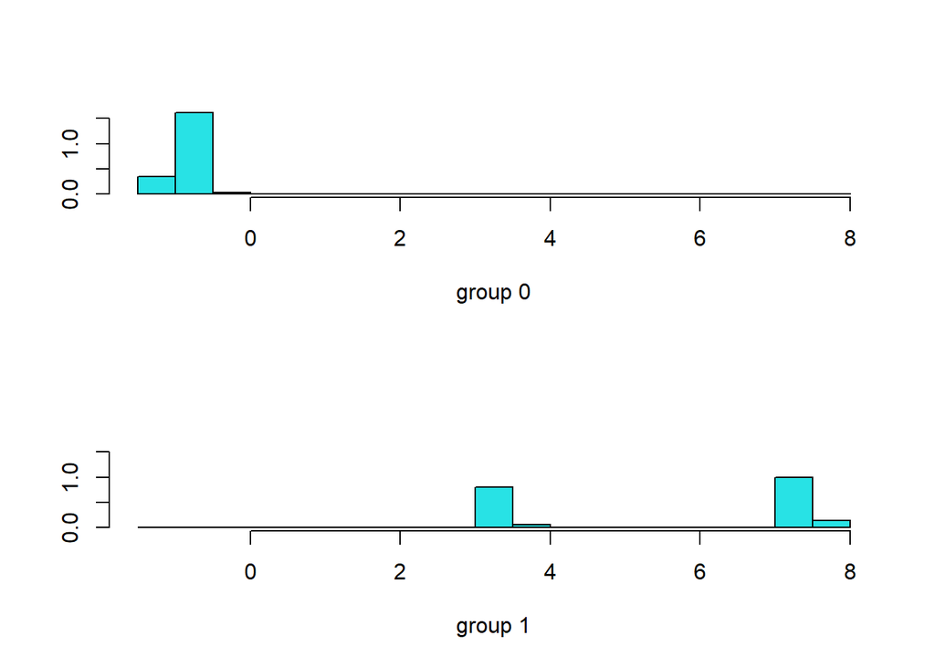

LD1 does a great job separating the different classes in a single dimension, there are almost no overlaps between normal and abnormal bidding behaviour (Finnstats, 2021). This result suggests high predictive accuracy in the classification algorithms that were applied in the following sections.

# **Machine Learning**

The concept of Machine Learning is a measurable improvement in a computer program’s function as it performance improves as it is presented with more data. Machine Learning algorithm are built to handle three different types of task, clustering, regression and classification. To solve these tasks the analyst has to decide using his experience the appropriate method to select between reinforcement learning, supervised learning, unsupervised learning, and semi-supervised learning, considering that each method is pertinent to different types of data (Ray, 2019).

## **Clustering algorithms**

Clustering is a valuable set of methods used in many applications, these unsupervised algorithms divide the features into classes, this division is based on data patterns identified by the algorithm, and the objects are grouped on the defined class based on similar behaviour (Dubey and Choubey, 2017). For the following algorithms, the also unsupervised PCA transformed data was applied, since this method resulted in a more sparse distribution of observations that contributes to better grouping and visualization.

### **K-Means Clustering**

This clustering algorithm is the most widely employed, the goal of K-Means unsupervised technique is to partition the observations into k clusters so the observations can be grouped based on the closest mean (Dubey and Choubey, 2017).

#### **SBD K-Means Clustering**

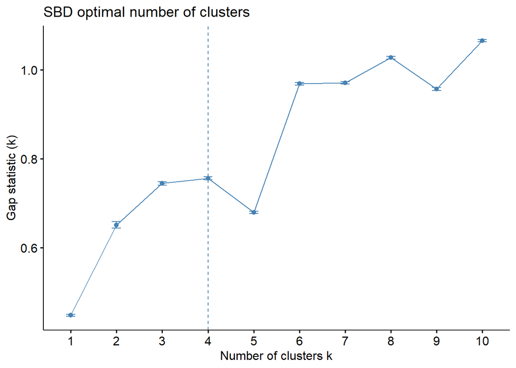

Elbow and silhouette methods only measure global clustering elements, as a more refined method gap statistics formalize these methods in a heuristic statistical in order to evaluate the ideal number of cluster that should be applied in the k-means algorithm (Tibshirani, Walther and Hastie, 2001).

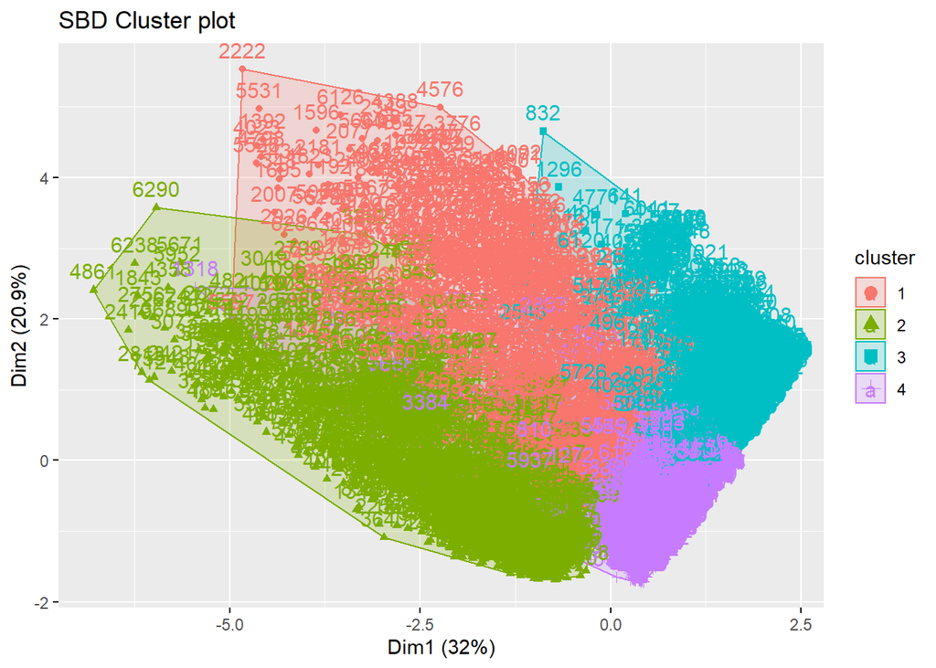

Setting four different clusters better identify the nature of the features related to normal and abnormal observations. The scatter plot displays the separation of the clusters by colour, each colour associated with one cluster. As we know, based on the class feature, which is not being used on unsupervised algorithms like k-means and hierarchical agglomerative clustering. The data is supposed to be divided into two categories, however, the normal bidding behaviour has a way bigger proportion than abnormal behaviour, thus being subjected to multiple patterns within itself (Maklin, 2019).

#### **PCA transformed K-Means Clustering**

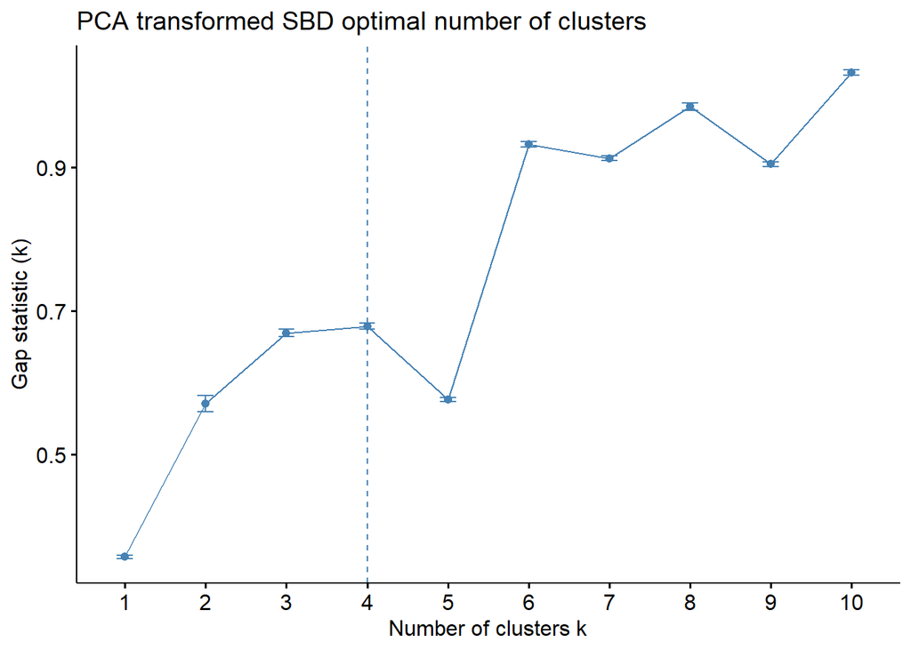

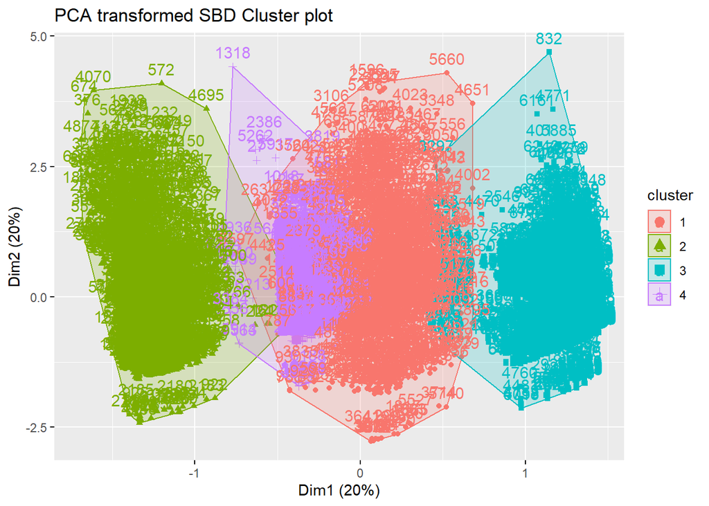

As exhibited in the scatter plot above the PCA transformed data achieve a fantastic job dividing the data into 4 different clusters, mainly on the x-axis.

### **Hierarchical Agglomerative Clustering**

As with other multivariate methods, the implemented hierarchical agglomerative clustering algorithm is an essential tool for the embedded classification of numerical features using sets of variables. This method is usually applied when the data has a large number of partitions each one correlated with a level of the hierarchy (Murtagh and Contreras, 2017).

#### **SBD Hierarchical Agglomerative Clustering**

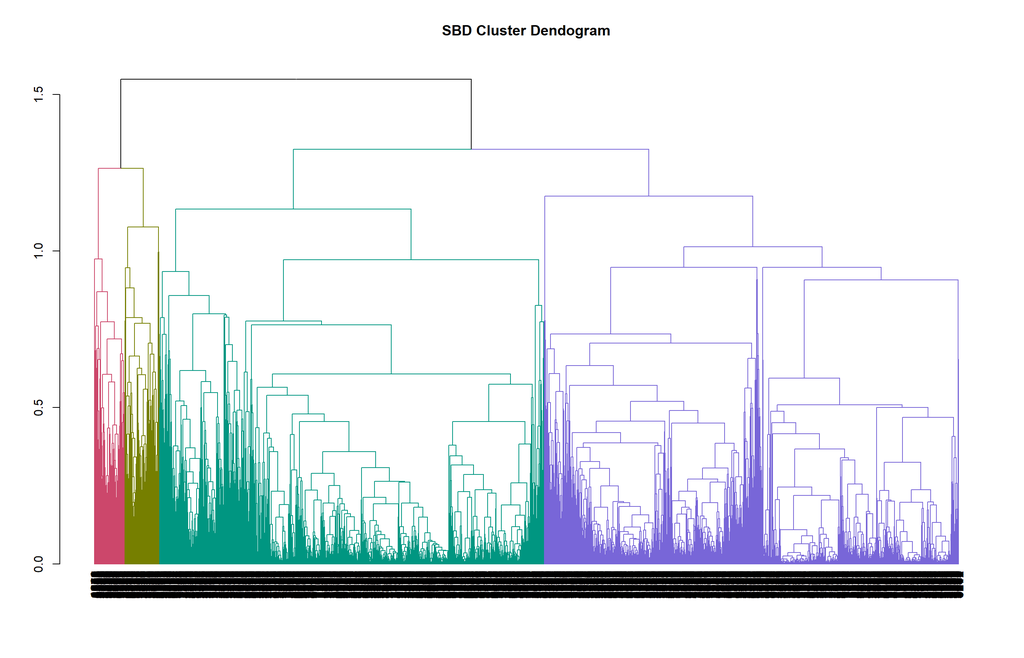

The dendrogram graphic representation above represents the number of partitions within the data. Asobserved, the ideal number of clusters is also four, as obtained in the k-means section, this is noticeable by inspecting the vertical axis (Maklin, 2019).

#### **PCA transformed Hierarchical Agglomerative Clustering**

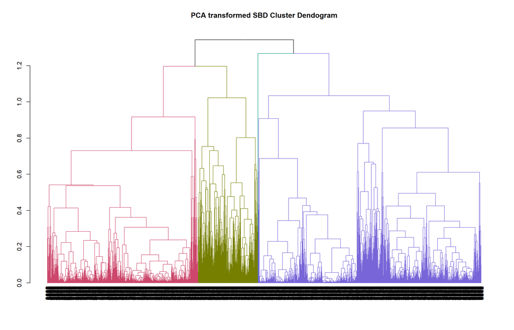

Both K-Means and Hierarchical Agglomerative Clustering exhibited similar results, indicating four patterns, being the normal data with three different patterns within itself and the abnormal data in a different fourth fashion, as suggested by the respective diagnostic plots. Both methods did an amazing job identifying and discriminating the different categories.

## **Classification algorithms**

Applied in both structured and unstructured data, classification algorithms aim is to learn from training data in order to label new data into a specific class (Sen, Hajra and Ghosh, 2019).

### **Random Forest Classification**

The Random Forest Classification technique can be applied in both regression and classification, this supervised learning methodology performs well with numerous and imbalanced datasets, dealing with missing data efficiently (More and Rana, 2017).

#### **SBD Random Forest Classification**

```
##
## Call:
##  randomForest(formula = Class ~ ., data = training_set, importance = TRUE,      proximity = TRUE)
##                Type of random forest: classification
##                      Number of trees: 500
## No. of variables tried at each split: 2
##
##         OOB estimate of  error rate: 0.65%
## Confusion matrix:
##      0   1 class.error
## 0 4498  19 0.004206332
## 1   14 526 0.025925926
```

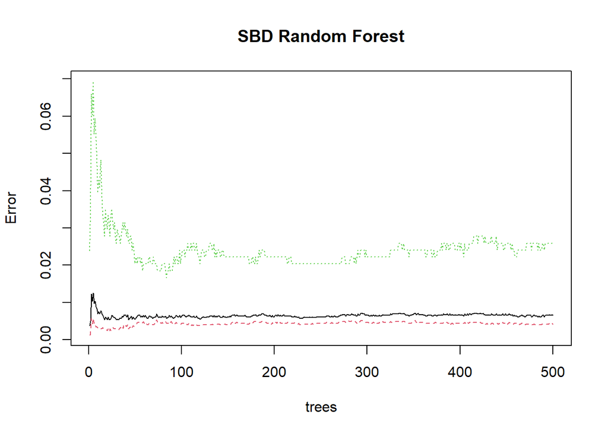

The non-transformed data were fitted in the random forest classifier method and resulted in an estimated error rate of 0.65% after running 500 decision trees, which is extremely good. The confusion matrix shows the superb predictive power of the model.However, The fact that not every good and precise model performs as accurate in real-world scenarios should be considered (Kumar, 2020). The same code was adapted and applied to the data transformed by the LDA method, and the results compared.

#### **LDA transformed Random Forest Classification**

```
##
## Call:
##  randomForest(formula = class ~ ., data = training_set_lda, importance = TRUE,      proximity = TRUE)
##                Type of random forest: classification
##                      Number of trees: 500
## No. of variables tried at each split: 1
##
##         OOB estimate of  error rate: 0%
## Confusion matrix:
##      0   1 class.error
## 0 4388   0           0
## 1    0 669           0
```

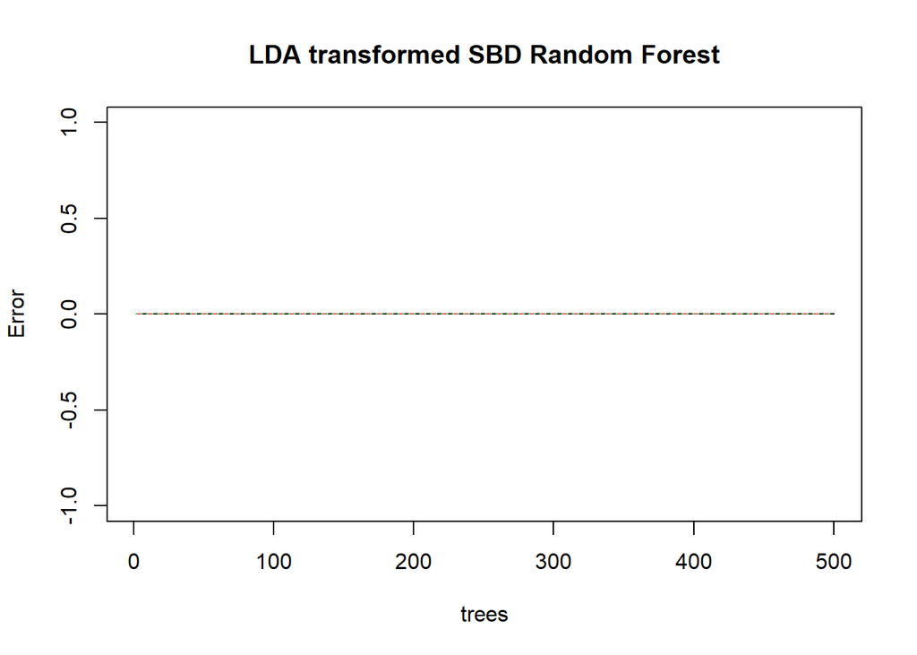

### **K-Nearest Neighbours**

Mostly used as a classifier, K-Nearest Neighbours or KNN method do its calculations using euclidean distance. This supervised non-parametric method is known for its simplicity and efficacy (Taunk et al., 2019).

#### **SBD K-Nearest Neighbours**

```
##    classifier_knn
##        0    1
##   0 1129    0
##   1    0  135
```

```
## [1] "SBD Accuracy = 1"
```

#### **LDA transformed K-Nearest Neighbours**

```
##    classifier_knn_lda
##        0    1
##   0 1090    0
##   1    0  174
```

```
## [1] "LDA transformed SBD Accuracy = 1"
```

The K-Nearest Neighbours prediction using Euclidean distance is displayed by the confusion matrix with 100% precision in both transformed and non-transformed data, this 100% accuracy score is similar to the one obtained in the previous method.

### **Decision Tree**

Another supervised method, decision tree method combines a sequence of straightforward techniques, in which each one makes use of a threshold value as a metric against possible values, this method classifies the data that fall in a particular region as integrated to the most recurrent class in that region. The decision tree’s main goal is to depict a tree with its findings data patterns accomplished by checking which test best separate the different cases into classes (Kotsiantis, 2011).

#### **SBD Decision tree**

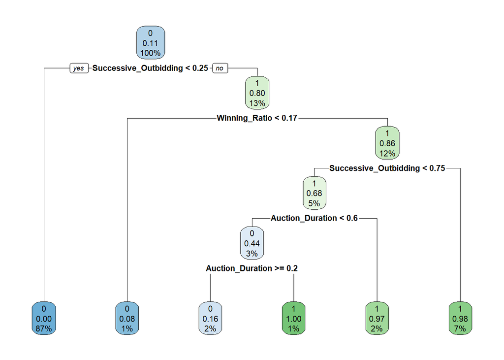

```
##
## Classification tree:
## rpart(formula = Class ~ ., data = training_set)
##
## Variables actually used in tree construction:
## [1] Auction_Duration      Successive_Outbidding Winning_Ratio
##
## Root node error: 540/5057 = 0.10678
##
## n= 5057
##
##         CP nsplit rel error   xerror     xstd
## 1 0.753704      0  1.000000 1.000000 0.040671
## 2 0.077778      1  0.246296 0.246296 0.021074
## 3 0.038272      2  0.168519 0.174074 0.017787
## 4 0.010000      5  0.053704 0.057407 0.010279
```

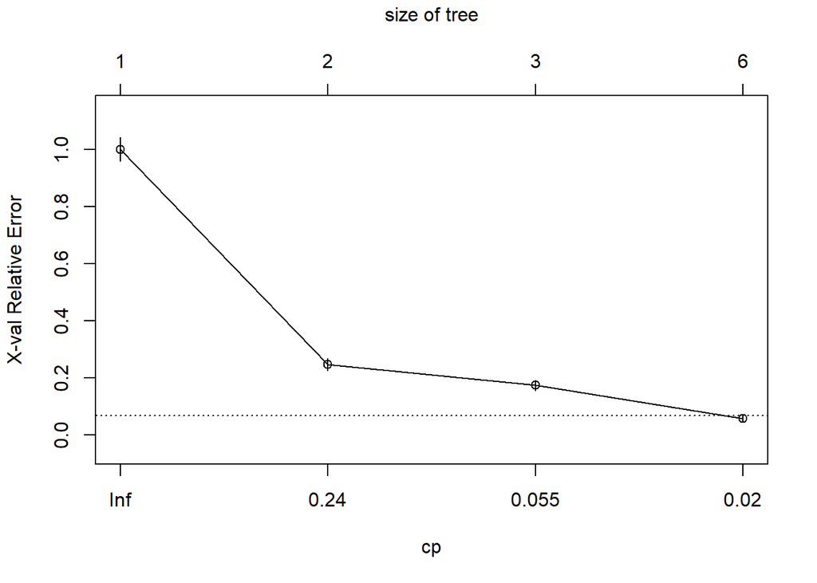

```
## Confusion Matrix and Statistics
##
##           Reference
## Prediction    0    1
##          0 4508   20
##          1    9  520
##
##                Accuracy : 0.9943
##                  95% CI : (0.9918, 0.9962)
##     No Information Rate : 0.8932
##     P-Value [Acc > NIR] : < 2e-16
##
##                   Kappa : 0.9697
##
##  Mcnemar's Test P-Value : 0.06332
##
##             Sensitivity : 0.9980
##             Specificity : 0.9630
##          Pos Pred Value : 0.9956
##          Neg Pred Value : 0.9830
##              Prevalence : 0.8932
##          Detection Rate : 0.8914
##    Detection Prevalence : 0.8954
##       Balanced Accuracy : 0.9805
##
##        'Positive' Class : 0
##
```

Amazing 99.4% accuracy obtained, the confusion matrix only reported nine false negatives, and twenty false positives in 5057 observation.

[figure not shown]

ROC curves can be employed to distinguish the balance of sensitivity and specificity when dealing with binary classifiers, the result can be interpreted as a measure of the predictive robustness of a model (Horton, 2016). As expected from the previous results the ROC curve displays a result close to perfection, the bidding behaviour is indeed very predictable as observed in the true positive rate (y-axis) versus false positive rate (x-axis) as also shown in the confusion matrix.

#### **LDA transformed Decision tree**

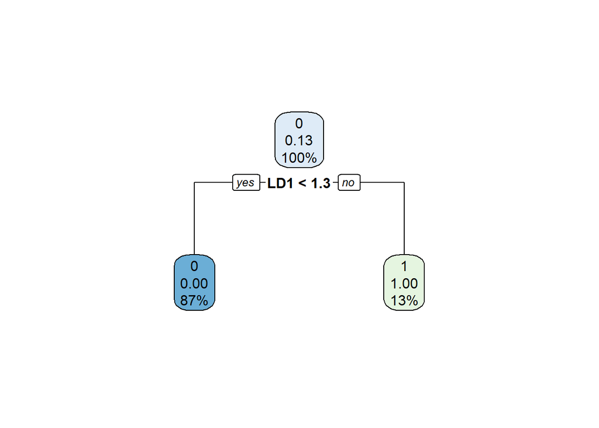

The single dimensionality of the LDA transformed data allows the decision tree to cover the complexity of the data set in a unique partitioning

```
##
## Classification tree:
## rpart(formula = class ~ ., data = training_set_lda)
##
## Variables actually used in tree construction:
## [1] LD1
##
## Root node error: 669/5057 = 0.13229
##
## n= 5057
##
##     CP nsplit rel error xerror     xstd
## 1 1.00      0         1      1 0.036014
## 2 0.01      1         0      0 0.000000
```

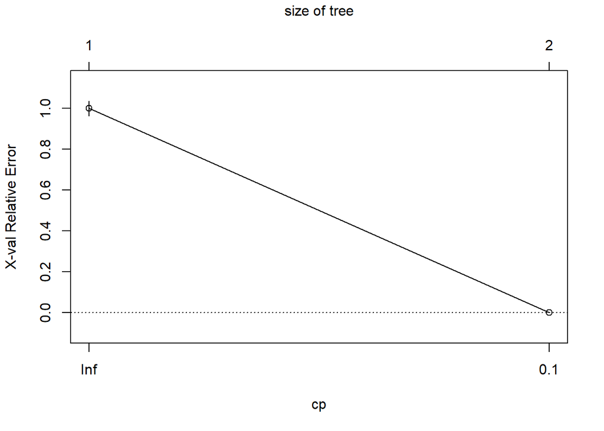

```
## Confusion Matrix and Statistics
##
##           Reference
## Prediction    0    1
##          0 4388    0
##          1    0  669
##
##                Accuracy : 1
##                  95% CI : (0.9993, 1)
##     No Information Rate : 0.8677
##     P-Value [Acc > NIR] : < 2.2e-16
##
##                   Kappa : 1
##
##  Mcnemar's Test P-Value : NA
##
##             Sensitivity : 1.0000
##             Specificity : 1.0000
##          Pos Pred Value : 1.0000
##          Neg Pred Value : 1.0000
##              Prevalence : 0.8677
##          Detection Rate : 0.8677
##    Detection Prevalence : 0.8677
##       Balanced Accuracy : 1.0000
##
##        'Positive' Class : 0
##
```

[figure not shown]

The LDA transformed data resulted in perfect predictions, reporting even better results than the already exceptional obtained from the untransformed data.

### **Comparison of ML algorithms for Classification**

Every single supervised algorithm resulted in an outstanding performance, Random Forest Classification, K-Nearest Neighbours and Decision Tree resulted in an accuracy score of over 98% on SBD predictions and 100% on LDA transformed data, with minor differences between them. K-Nearest Neighbours had the best accuracy score, however, the difference is negligible, it is safe to say that all algorithms applied are suitable for predictions on SBD.

# **Conclusion**

As a result of the dimensionality reduction methods, it was observed that the PCA empowered the clustering methods with a higher level of discrimination between groups. Scaled PCA resulted in more sparsed observations in the two-dimensional plot. The three classification methods employed in this report had magnificent results, especially K-Nearest Neighbours, achieving perfect predictions in both LDA-transformed and untransformed data. The LDA methods resulted in a more versatile one dimensionaç analysis, with a clear separation between classes, easily observed in diagnostic graphics.

Three supervised algorithms were implemented for classification purposes, Random Forest, K-Nearest Neighbours and Decision Tree. Every single one of these algorithms resulted in an outstanding accuracy score, being excellent in extracting predictions for the normal and abnormal bidding behaviour, exceptionally normal, because of the massive amount of observation that falls into this category. Two clustering methods were applied for the unsupervised algorithms using the PCA transformed data, K-Means Clustering and Hierarchical Agglomerative Clustering. It was observed in both algorithms clear division of the data into four distinct patterns, three associated with normal bidding behaviour and one with abnormal.

# **References**

Alzahrani, A. and Sadaoui, S. (2018). Scraping and preprocessing commercial auction data for fraud classification.

Analytics Vidhya. (2021). Tackling Missing Value in Dataset. [online] Available at: https://www.analyticsvidhya.com/blog/2021/10/handlingmissing-value/#:~:text=Missing%20value%20can%20bias%20the [Accessed 28 Apr. 2022].

Asaithambi, S. (2017). Why, How and When to Scale your Features. [online] Medium. Available at: https://medium.com/greyatom/why-howand-when-to-scale-your-features-4b30ab09db5e.

Askpython (2020). Split Training and Testing Data Sets in Python - AskPython. [online] Available at: https://www.askpython.com/python/examples/split-data-training-and-testing-set#:~:text=The%20most%20common%20split%20ratio [Accessed 19 May 2022].

Capozzoli, A., Cerquitelli, T. and Piscitelli, M.S. (2016). Enhancing energy efficiency in buildings through innovative data analytics technologiesa. Pervasive Computing, pp.353–389

Dubey, A. and Choubey, A.P.D.A., 2017. A systematic review on k-means clustering techniques. Int J Sci Res Eng Technol (IJSRET, ISSN 2278–0882), 6(6).

Duvva, P. (2021). LDA vs. PCA – Towards AI. [online] Available at: https://towardsai.net/p/data-science/lda-vspca#:~:text=LDA%20focuses%20on%20finding%20

Finnstats (2021). Linear Discriminant Analysis in R | R-bloggers. [online] Available at: https://www.r-bloggers.com/2021/05/linear-discriminant-analysis-in-r/.

Galarnyk, M. (2018). Understanding Boxplots. [online] Medium. Available at: https://towardsdatascience.com/understanding-boxplots5e2df7bcbd51.

GeeksforGeeks. (2020). Normalization vs Standardization. [online] Available at: https://www.geeksforgeeks.org/normalization-vsstandardization/ [Accessed 1 May 2022].

Han, J., Kamber, M. and Pei, J. (2012). Introduction. Data Mining, pp.1–38.

Hayden, L.(2018). R PCA Tutorial (Principal Component Analysis). [online] Available at: https://www.datacamp.com/tutorial/pca-analysis-r [Accessed 16 Jun. 2022].

Horton, B.(2016). ROC Curves in Two Lines of R Code. [online] Available at: https://blog.revolutionanalytics.com/2016/08/roc-curves-in-two-lines-of-code.html#:~:text=ROC%20curves%20are%20commonly%20used [Accessed 20 Jun. 2022].

Hunt, C. (2019). Why you shouldn’t use pie charts. [online] Statistical Consulting Centre. Available at: https://scc.ms.unimelb.edu.au/resources-list/data-visualisation-and-exploration/no_piecharts#:~:text=Pies%20and%20doughnuts%20fail%20because [Accessed 27 Apr. 2022]

Johnson, D.(2022). Decision Tree in R with Example. [online] Available at: https://www.guru99.com/r-decision-trees.html.

Jolliffe, I.T. and Cadima, J. (2016). Principal component analysis: a review and recent developments. Philosophical Transactions of the Royal Society A: Mathematical, Physical and Engineering Sciences, 374(2065), p.20150202. doi:10.1098/rsta.2015.0202.

Khurana, U., Samulowitz, H. and Turaga, D. (2018) “Feature Engineering for Predictive Modeling Using Reinforcement Learning”, Proceedings of the AAAI Conference on Artificial Intelligence, 32(1). Available at: https://ojs.aaai.org/index.php/AAAI/article/view/11678

Kohli, S. (2019). Understanding a Classification Report For Your Machine Learning Model. [online] Medium. Available at: https://medium.com/@kohlishivam5522/understanding-a-classification-report-for-your-machine-learning-model-88815e2ce397.

Kotsiantis, S.B. (2011). Decision trees: a recent overview. Artificial Intelligence Review, 39(4), pp.261–283. doi:10.1007/s10462-011-9272-4.

Kumar, S. (2020). 9 Reasons why Machine Learning models not perform well in production. [online] Medium. Available at: https://towardsdatascience.com/9-reasons-why-machine-learning-models-not-perform-well-in-production-4497d3e3e7a5 [Accessed 20 May 2022].

Maklin, C. (2019). K-means Clustering Python Example. [online] Medium. Available at: https://towardsdatascience.com/machine-learningalgorithms-part-9-k-means-example-in-python-f2ad05ed5203.

More, A.S. and Rana, D.P. (2017). Review of random forest classification techniques to resolve data imbalance. 2017 1st International Conference on Intelligent Systems and Information Management (ICISIM). doi:10.1109/icisim.2017.8122151.

Murtagh, F. and Contreras, P. (2017). Algorithms for hierarchical clustering: an overview, II. Wiley Interdisciplinary Reviews: Data Mining and Knowledge Discovery, 7(6), p.e1219. doi:10.1002/widm.1219.

Ray, S. (2019). A Quick Review of Machine Learning Algorithms. [online] IEEE Xplore. doi:10.1109/COMITCon.2019.8862451.

Sen, P.C., Hajra, M. and Ghosh, M. (2019). Supervised Classification Algorithms in Machine Learning: A Survey and Review. Advances in Intelligent Systems and Computing, pp.99–111. doi:10.1007/978-981-13-7403-6_11.

Sharma, A. and Paliwal, K.K. (2014). Linear discriminant analysis for the small sample size problem: an overview. International Journal of Machine Learning and Cybernetics, 6(3), pp.443–454. doi:10.1007/s13042-013-0226-9.

Sullivan, J. (2018). Data Cleaning with Python and Pandas: Detecting Missing Values. [online] Medium. Available at: https://towardsdatascience.com/data-cleaning-with-python-and-pandas-detecting-missing-values-3e9c6ebcf78b.

Taunk, K., De, S., Verma, S. and Swetapadma, A. (2019). A Brief Review of Nearest Neighbor Algorithm for Learning and Classification. [online] IEEE Xplore. doi:10.1109/ICCS45141.2019.9065747.

Tibshirani, R., Walther, G. and Hastie, T. (2001). Estimating the number of clusters in a data set via the gap statistic. Journal of the Royal Statistical Society: Series B (Statistical Methodology), [online] 63(2), pp.411–423. doi:10.1111/1467-9868.00293.

Zach (2020). Linear Discriminant Analysis in R (Step-by-Step). [online] Statology. Available at: https://www.statology.org/linear-discriminant-analysis-in-r/.